# Crime Project by M. Fraser-Philbin and T. Bastasch

Authors:  
Thomas Bastasch  
Maya Philbin

# Introduction

This project includes data from a 2013 study on Crime in the US conducted by the FBI. The data includes information about the motivation of crimes and the offender’s race. In this project, we look specifically at the motivations of crimes against people and the criminal demographics.

```r
#Setup
library("xlsx", lib.loc="~/R/win-library/3.2")
```

```r
library(tidyr)
library(ggplot2)
library(dplyr)
setwd("~/")
victim.person <- read.xlsx('crimes.biasmotive.xls',1)

victim.person <- victim.person[-c(27:28),-c(10:17)]

crime.race <- read.xlsx('crimes.biasmotive.xls',2)
crime.race <- crime.race[-c(27),]
```

# 1.) What is the breakdown of White Criminal Motivation?

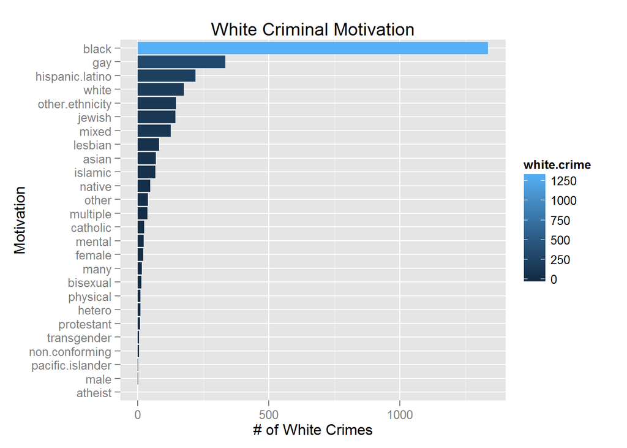

```r
ggplot(crime.race, aes(x = reorder(motivation,white.crime), y = white.crime, fill = white.crime)) + geom_bar(stat = "identity") + coord_flip() + labs(x = "Motivation", y = "# of White Crimes", title = "White Criminal Motivation")
```

Conclusion:  
This graph displays the count of crimes white criminals have done based on their motivation. The highest count of crimes done by white people in 2013 held motivation against black people and the least count were motivated against Atheism.It seems the only real bias white crime has is a motivation against black people.

# 2.) What is the relationship between Simple Assault and Motivation?

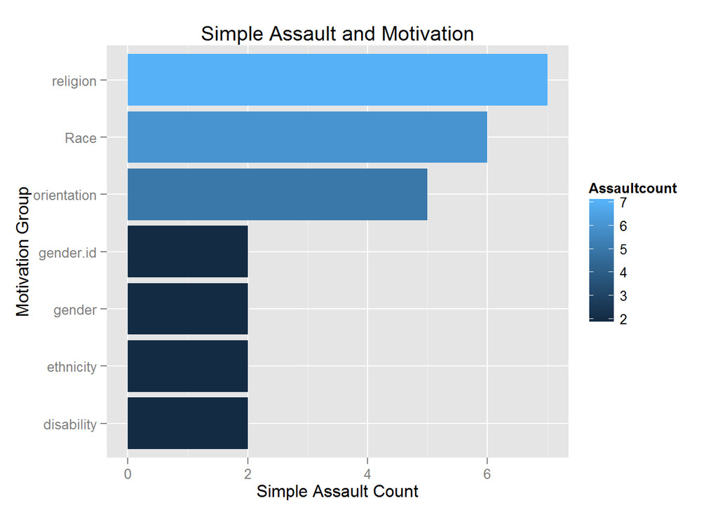

```r
sam = victim.person %>% group_by(group.bias) %>% summarize(Assaultcount = length(simple.assault))

ggplot(sam, aes(x = reorder(group.bias,Assaultcount), y = Assaultcount, fill = Assaultcount)) + geom_bar(stat = "identity") + coord_flip() + labs(y = "Simple Assault Count", x = "Motivation Group", title = "Simple Assault and Motivation")
```

# 3.) What is the mean Intimidation crime inflicted on a given group?

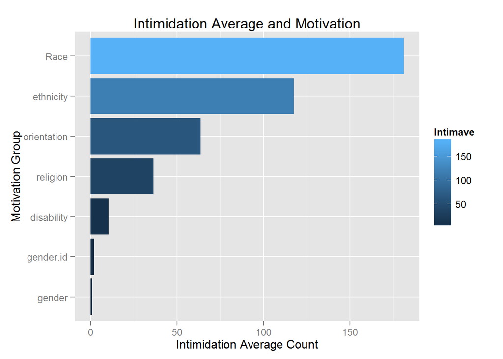

```r
iog = victim.person %>% group_by(group.bias) %>% summarize(Intimave = mean(intimidation))

ggplot(iog, aes(x = reorder(group.bias,Intimave), y = Intimave, fill = Intimave)) + geom_bar(stat = "identity") + coord_flip() + labs(y = "Intimidation Average Count", x = "Motivation Group", title = "Intimidation Average and Motivation")
```

Conclusion:  
This graph groups biases like the last, but this one compares such data with the averages of intimidation crimes. Here we found race and ethnicity to be the biggest motivations.

# 4.) What is the breakdown of black criminals committing crimes motivated by Sexual Orientation?

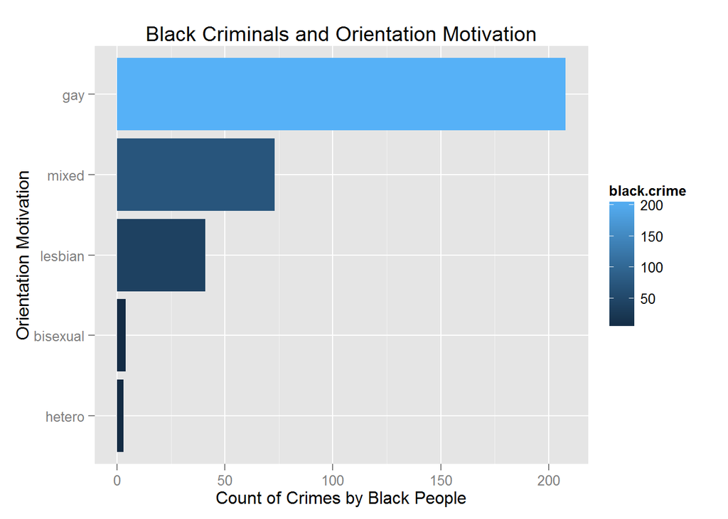

```r
bmso <- crime.race[(14:18),]

ggplot(bmso, aes(x = reorder(motivation,black.crime), y = black.crime, fill = black.crime)) + geom_bar(stat = "identity") + coord_flip() + labs(y = "Count of Crimes by Black People", x = "Orientation Motivation", title = "Black Criminals and Orientation Motivation")
```

Conclusion:  
Finally, this plot demonstrates the crimes done by black people and the count of motivations for different sexual orientations. We have found that there was significantly high amounts of black crimes committed against gay people.